# Chebyshev’s Inequality & The CLT - Homework 3

Suppose $X \sim \text{exponential}(\lambda)$ with mean $\mu$ and variance $\sigma^2$. This means $\mu = E[X]=\frac{1}{\lambda}$ and $\sigma^2 = \text{Var}[X] = \frac{1}{\lambda^2}.$ We firstly obtain $\Pr(|X-\mu| \geq k\sigma)$.

Firstly notice that $\Pr(|X-\mu| \geq k\sigma) = \Pr(X-\mu \geq k\sigma)+\Pr(X-\mu \leq -k\sigma)$. By substituting the mean and standard deviation in terms of the parameter $\lambda$ we obtain $\Pr(|X-\mu| \geq k\sigma) = \Pr(X-\frac{1}{\lambda} \geq \frac{k}{\lambda})+\Pr(X-\frac{1}{\lambda} \leq -\frac{k}{\lambda}) = \Pr(X \geq \frac{k+1}{\lambda})+\Pr(X \leq \frac{1-k}{\lambda}) = (1 - \Pr(X \leq \frac{k+1}{\lambda}))+\Pr(X \leq \frac{1-k}{\lambda})$.

Recognising $F_X(x) = \Pr(X \leq x)$, and for the exponential distribtuion we have $F_X(x) = 1 - \exp(-\lambda x)$. Using this we have $(1 - \Pr(X \leq \frac{k+1}{\lambda}))+\Pr(X \leq \frac{1-k}{\lambda}) = (1-F_X(\frac{k+1}{\lambda})) + F_X(\frac{1-k}{\lambda}).$

By applying the definition of the CDF for the exponential distribution we finally obtain $(1-F_X(\frac{k+1}{\lambda})) + F_X(\frac{1-k}{\lambda}) = 1 + \exp(-(k+1)) - \exp(k-1).$

```r
k=seq(1.0, 5.0, 0.5) #Vector containing k values
prob = exp(-(k+1)) #Probability vector for k values - Choose appropriate bit for k>1
chebyshev=1/k^2 #Chebyshev probability vector
DF=data.frame(K=k,ExactProb=prob, ChebyBound=chebyshev)
DF
```

| K | ExactProb | ChebyBound |
| --- | --- | --- |
| 1.0 | 0.135335283 | 1.00000000 |
| 1.5 | 0.082084999 | 0.44444444 |
| 2.0 | 0.049787068 | 0.25000000 |
| 2.5 | 0.030197383 | 0.16000000 |
| 3.0 | 0.018315639 | 0.11111111 |
| 3.5 | 0.011108997 | 0.08163265 |
| 4.0 | 0.006737947 | 0.06250000 |
| 4.5 | 0.004086771 | 0.04938272 |
| 5.0 | 0.002478752 | 0.04000000 |

We then plot the exact probability values against the Chebyshev bound values to see the probability is smaller than the Chbyshev bound at each point.

```r
plot(k, prob, type="l", ylim=c(0,1), lwd = 2, ylab = "Probability")
points(k,chebyshev,type="l",lty=2,col='red', lwd = 2)
```

[figure not shown]

```r
legend(4, 0.95, legend=c("Exact Probability", "Chebyshev Bound"), col=c("black", "red"), lty=1:2, cex=0.8)
```

For this we make use of the function provided in Notebook 4. Simply adjusting the parameters such that “mean=$\lambda$” and “sd=sqrt($\lambda$)/sqrt(rvs)” provides the necessary plots.

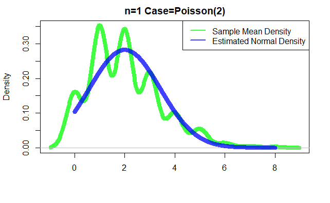

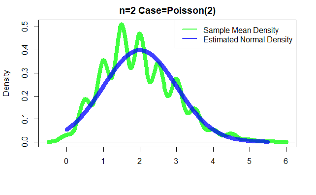

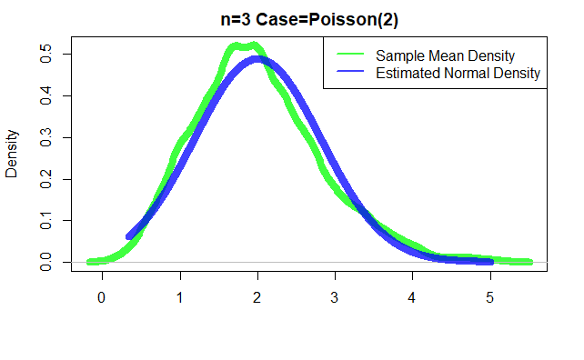

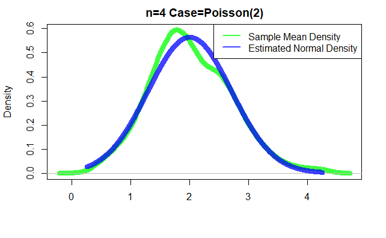

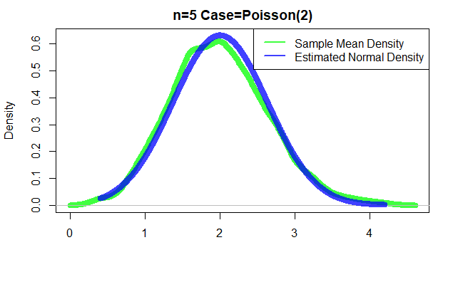

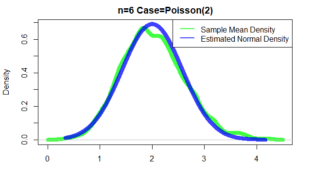

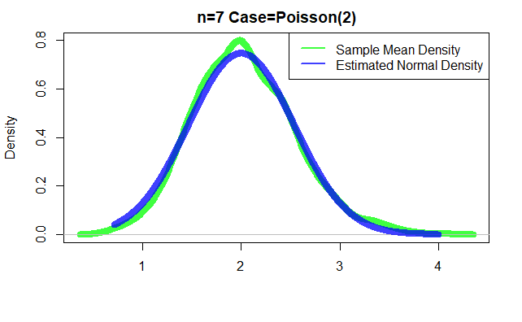

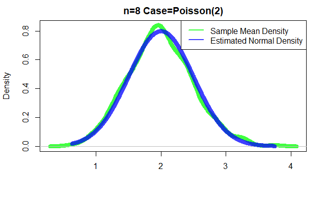

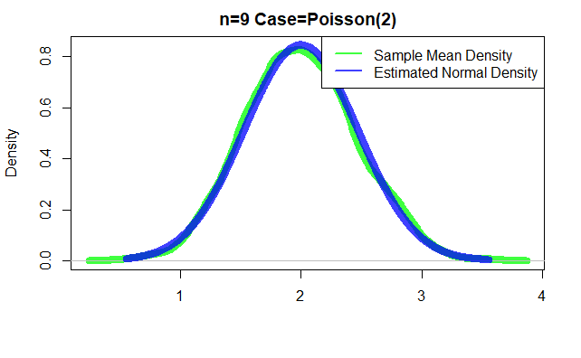

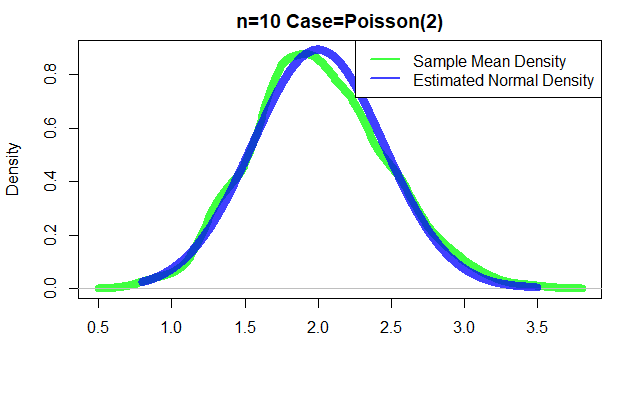

```r
outputplotCLT <- function(rvs){
  #define number of sample means
  samp = 1000
  #in the following we sample according to the selected distribution
  #the number of rows is the number of sample means,
  #the number of columns is the sample size
  #calculate the mean and sd of the approximate normal in both cases
  matrix = matrix(rpois(rvs*samp, 2), nrow = samp, ncol = rvs)
  mu = 2 #check these
  sd = sqrt(2)/sqrt(rvs)


  #calculate the means from each sample
  means = rowMeans(matrix)
  #find the fit for the normal (estimate parameters)
  xfit = seq(from = min(means), to = max(means), by = .001)
  yfit = dnorm(xfit, mean = mu, sd = sd)
  #plot means, overlay Normal distribution
  plot(density(means), main = "", xlab = "", ylab = "Density", col = rgb(0, 1, 0, 3/4), lwd = 8, ylim = c(0, max(density(means)$y, yfit)))
  lines(xfit, yfit, col = rgb(0, 0, 1, 3/4), lwd = 8)
  title(main = paste(c("n=",rvs," Case=Poisson(2)"),collapse=''))
  legend("topright", legend = c("Sample Mean Density", "Estimated Normal Density"), lty=c(1,1), lwd=c(2.5,2.5), col=c(rgb(0, 1, 0, 3/4), rgb(0, 0, 1, 3/4)))
}
for(samplesize in seq(1,10)) {
  outputplotCLT(samplesize)
}
```